# chapter7 - Basic statistics

alfonso

May 19, 2016

# 描述性统计

## 统计方法概览

**峰态**：表征概率密度分布曲线在平均值处峰值高低的特征数。直观看来，峰度反映了尾部的厚度。正态分布的峰度为3，小于3则说明更扁平一些。  
**偏态**：是指非对称分布的偏斜状态。换句话说，就是指统计总体当中的变量值分别落在众数（M0）的左右两边，呈非对称性分布。为正表示偏右。

```r
vars <- c("mpg", "hp", "wt")
head(mtcars[vars])
```

```
##                    mpg  hp    wt
## Mazda RX4         21.0 110 2.620
## Mazda RX4 Wag     21.0 110 2.875
## Datsun 710        22.8  93 2.320
## Hornet 4 Drive    21.4 110 3.215
## Hornet Sportabout 18.7 175 3.440
## Valiant           18.1 105 3.460
```

```r
summary(mtcars[vars])
```

```
##       mpg              hp              wt
##  Min.   :10.40   Min.   : 52.0   Min.   :1.513
##  1st Qu.:15.43   1st Qu.: 96.5   1st Qu.:2.581
##  Median :19.20   Median :123.0   Median :3.325
##  Mean   :20.09   Mean   :146.7   Mean   :3.217
##  3rd Qu.:22.80   3rd Qu.:180.0   3rd Qu.:3.610
##  Max.   :33.90   Max.   :335.0   Max.   :5.424
```

```r
# summary没有提供 skew偏态，kurtosis峰态
mystats <- function(x, na.omit = FALSE) {
  if (na.omit)
    x <- x[!is.na(x)]
  m <- mean(x)
  n <- length(x)
  s <- sd(x)
  skew <- sum((x-m)^3/s^3)/n
  kurt <- sum((x-m)^4/s^4)/n - 3
  return(c(n = n, mean = m, stdev = s, skew = skew, kurtosis = kurt))
}

sapply(mtcars[vars], mystats)
```

```
##                mpg          hp          wt
## n        32.000000  32.0000000 32.00000000
## mean     20.090625 146.6875000  3.21725000
## stdev     6.026948  68.5628685  0.97845744
## skew      0.610655   0.7260237  0.42314646
## kurtosis -0.372766  -0.1355511 -0.02271075
```

```r
library(Hmisc)
describe(mtcars[vars])
```

```
## mtcars[vars]
##
##  3  Variables      32  Observations
## ---------------------------------------------------------------------------
## mpg
##       n missing  unique    Info    Mean     .05     .10     .25     .50
##      32       0      25       1   20.09   12.00   14.34   15.43   19.20
##     .75     .90     .95
##   22.80   30.09   31.30
##
## lowest : 10.4 13.3 14.3 14.7 15.0, highest: 26.0 27.3 30.4 32.4 33.9
## ---------------------------------------------------------------------------
## hp
##       n missing  unique    Info    Mean     .05     .10     .25     .50
##      32       0      22       1   146.7   63.65   66.00   96.50  123.00
##     .75     .90     .95
##  180.00  243.50  253.55
##
## lowest :  52  62  65  66  91, highest: 215 230 245 264 335
## ---------------------------------------------------------------------------
## wt
##       n missing  unique    Info    Mean     .05     .10     .25     .50
##      32       0      29       1   3.217   1.736   1.956   2.581   3.325
##     .75     .90     .95
##   3.610   4.048   5.293
##
## lowest : 1.513 1.615 1.835 1.935 2.140
## highest: 3.845 4.070 5.250 5.345 5.424
## ---------------------------------------------------------------------------
```

```r
library(pastecs)
stat.desc(mtcars[vars])
```

```
##                      mpg           hp          wt
## nbr.val       32.0000000   32.0000000  32.0000000
## nbr.null       0.0000000    0.0000000   0.0000000
## nbr.na         0.0000000    0.0000000   0.0000000
## min           10.4000000   52.0000000   1.5130000
## max           33.9000000  335.0000000   5.4240000
## range         23.5000000  283.0000000   3.9110000
## sum          642.9000000 4694.0000000 102.9520000
## median        19.2000000  123.0000000   3.3250000
## mean          20.0906250  146.6875000   3.2172500
## SE.mean        1.0654240   12.1203173   0.1729685
## CI.mean.0.95   2.1729465   24.7195501   0.3527715
## var           36.3241028 4700.8669355   0.9573790
## std.dev        6.0269481   68.5628685   0.9784574
## coef.var       0.2999881    0.4674077   0.3041285
```

```r
library(psych)
describe(mtcars[vars])
```

```
##     vars  n   mean    sd median trimmed   mad   min    max  range skew
## mpg    1 32  20.09  6.03  19.20   19.70  5.41 10.40  33.90  23.50 0.61
## hp     2 32 146.69 68.56 123.00  141.19 77.10 52.00 335.00 283.00 0.73
## wt     3 32   3.22  0.98   3.33    3.15  0.77  1.51   5.42   3.91 0.42
##     kurtosis    se
## mpg    -0.37  1.07
## hp     -0.14 12.12
## wt     -0.02  0.17
```

## 分组统计

```r
aggregate(mtcars[vars], by=list(am=mtcars$am), mean)
```

```
##   am      mpg       hp       wt
## 1  0 17.14737 160.2632 3.768895
## 2  1 24.39231 126.8462 2.411000
```

```r
aggregate(mtcars[vars], by=list(am=mtcars$am), sd)
```

```
##   am      mpg       hp        wt
## 1  0 3.833966 53.90820 0.7774001
## 2  1 6.166504 84.06232 0.6169816
```

```r
dstats <- function(x) {
  # 原文这里有误，mean不能作用于data.frame
  return(c(mean=sapply(x, mean), sd=sapply(x, sd)))
}
by(mtcars[vars], mtcars$am, dstats)
```

```
## mtcars$am: 0
##    mean.mpg     mean.hp     mean.wt      sd.mpg       sd.hp       sd.wt
##  17.1473684 160.2631579   3.7688947   3.8339664  53.9081957   0.7774001
## --------------------------------------------------------
## mtcars$am: 1
##    mean.mpg     mean.hp     mean.wt      sd.mpg       sd.hp       sd.wt
##  24.3923077 126.8461538   2.4110000   6.1665038  84.0623243   0.6169816
```

```r
library(doBy)
summaryBy(mpg+hp+wt~am, data=mtcars, FUN=mystats)
```

```
##   am mpg.n mpg.mean mpg.stdev   mpg.skew mpg.kurtosis hp.n  hp.mean
## 1  0    19 17.14737  3.833966 0.01395038   -0.8031783   19 160.2632
## 2  1    13 24.39231  6.166504 0.05256118   -1.4553520   13 126.8462
##   hp.stdev     hp.skew hp.kurtosis wt.n  wt.mean  wt.stdev   wt.skew
## 1 53.90820 -0.01422519  -1.2096973   19 3.768895 0.7774001 0.9759294
## 2 84.06232  1.35988586   0.5634635   13 2.411000 0.6169816 0.2103128
##   wt.kurtosis
## 1   0.1415676
## 2  -1.1737358
```

```r
library(psych)
describeBy(mtcars[vars], mtcars$am)
```

```
## group: 0
##     vars  n   mean    sd median trimmed   mad   min    max  range  skew
## mpg    1 19  17.15  3.83  17.30   17.12  3.11 10.40  24.40  14.00  0.01
## hp     2 19 160.26 53.91 175.00  161.06 77.10 62.00 245.00 183.00 -0.01
## wt     3 19   3.77  0.78   3.52    3.75  0.45  2.46   5.42   2.96  0.98
##     kurtosis    se
## mpg    -0.80  0.88
## hp     -1.21 12.37
## wt      0.14  0.18
## --------------------------------------------------------
## group: 1
##     vars  n   mean    sd median trimmed   mad   min    max  range skew
## mpg    1 13  24.39  6.17  22.80   24.38  6.67 15.00  33.90  18.90 0.05
## hp     2 13 126.85 84.06 109.00  114.73 63.75 52.00 335.00 283.00 1.36
## wt     3 13   2.41  0.62   2.32    2.39  0.68  1.51   3.57   2.06 0.21
##     kurtosis    se
## mpg    -1.46  1.71
## hp      0.56 23.31
## wt     -1.17  0.17
```

```r
library(reshape)
dstats <- function(x)(c(n=length(x), mean=mean(x), sd=sd(x)))
dfm <- melt(mtcars, measure.vars=c("mpg", "hp", "wt"),
              id.vars=c("am", "cyl"))
cast(dfm, am + cyl + variable ~ ., dstats)
```

```
##    am cyl variable  n       mean         sd
## 1   0   4      mpg  3  22.900000  1.4525839
## 2   0   4       hp  3  84.666667 19.6553640
## 3   0   4       wt  3   2.935000  0.4075230
## 4   0   6      mpg  4  19.125000  1.6317169
## 5   0   6       hp  4 115.250000  9.1787799
## 6   0   6       wt  4   3.388750  0.1162164
## 7   0   8      mpg 12  15.050000  2.7743959
## 8   0   8       hp 12 194.166667 33.3598379
## 9   0   8       wt 12   4.104083  0.7683069
## 10  1   4      mpg  8  28.075000  4.4838599
## 11  1   4       hp  8  81.875000 22.6554156
## 12  1   4       wt  8   2.042250  0.4093485
## 13  1   6      mpg  3  20.566667  0.7505553
## 14  1   6       hp  3 131.666667 37.5277675
## 15  1   6       wt  3   2.755000  0.1281601
## 16  1   8      mpg  2  15.400000  0.5656854
## 17  1   8       hp  2 299.500000 50.2045815
## 18  1   8       wt  2   3.370000  0.2828427
```

# 频率表和列联表

## 产生频率表

```r
library(vcd)
library(gmodels)
head(Arthritis)
```

```
##   ID Treatment  Sex Age Improved
## 1 57   Treated Male  27     Some
## 2 46   Treated Male  29     None
## 3 77   Treated Male  30     None
## 4 17   Treated Male  32   Marked
## 5 36   Treated Male  46   Marked
## 6 23   Treated Male  58   Marked
```

```r
(mytable <- with(Arthritis, table(Improved)))
```

```
## Improved
##   None   Some Marked
##     42     14     28
```

```r
prop.table(mytable) # 转化成百分比 prop.table(mytable)*100
```

```
## Improved
##      None      Some    Marked
## 0.5000000 0.1666667 0.3333333
```

```r
(mytable <- xtabs(~ Treatment+Improved, data=Arthritis))
```

```
##          Improved
## Treatment None Some Marked
##   Placebo   29    7      7
##   Treated   13    7     21
```

```r
margin.table(mytable, 1)
```

```
## Treatment
## Placebo Treated
##      43      41
```

```r
prop.table(mytable, 1)
```

```
##          Improved
## Treatment      None      Some    Marked
##   Placebo 0.6744186 0.1627907 0.1627907
##   Treated 0.3170732 0.1707317 0.5121951
```

```r
margin.table(mytable, 2)
```

```
## Improved
##   None   Some Marked
##     42     14     28
```

```r
prop.table(mytable, 2)
```

```
##          Improved
## Treatment      None      Some    Marked
##   Placebo 0.6904762 0.5000000 0.2500000
##   Treated 0.3095238 0.5000000 0.7500000
```

```r
addmargins(mytable)
```

```
##          Improved
## Treatment None Some Marked Sum
##   Placebo   29    7      7  43
##   Treated   13    7     21  41
##   Sum       42   14     28  84
```

```r
addmargins(prop.table(mytable))
```

```
##          Improved
## Treatment       None       Some     Marked        Sum
##   Placebo 0.34523810 0.08333333 0.08333333 0.51190476
##   Treated 0.15476190 0.08333333 0.25000000 0.48809524
##   Sum     0.50000000 0.16666667 0.33333333 1.00000000
```

```r
addmargins(prop.table(mytable, 1), 2)
```

```
##          Improved
## Treatment      None      Some    Marked       Sum
##   Placebo 0.6744186 0.1627907 0.1627907 1.0000000
##   Treated 0.3170732 0.1707317 0.5121951 1.0000000
```

```r
addmargins(prop.table(mytable, 2), 1)
```

```
##          Improved
## Treatment      None      Some    Marked
##   Placebo 0.6904762 0.5000000 0.2500000
##   Treated 0.3095238 0.5000000 0.7500000
##   Sum     1.0000000 1.0000000 1.0000000
```

```r
CrossTable(Arthritis$Treatment, Arthritis$Improved)
```

```
##
##
##    Cell Contents
## |-------------------------|
## |                       N |
## | Chi-square contribution |
## |           N / Row Total |
## |           N / Col Total |
## |         N / Table Total |
## |-------------------------|
##
##
## Total Observations in Table:  84
##
##
##                     | Arthritis$Improved
## Arthritis$Treatment |      None |      Some |    Marked | Row Total |
## --------------------|-----------|-----------|-----------|-----------|
##             Placebo |        29 |         7 |         7 |        43 |
##                     |     2.616 |     0.004 |     3.752 |           |
##                     |     0.674 |     0.163 |     0.163 |     0.512 |
##                     |     0.690 |     0.500 |     0.250 |           |
##                     |     0.345 |     0.083 |     0.083 |           |
## --------------------|-----------|-----------|-----------|-----------|
##             Treated |        13 |         7 |        21 |        41 |
##                     |     2.744 |     0.004 |     3.935 |           |
##                     |     0.317 |     0.171 |     0.512 |     0.488 |
##                     |     0.310 |     0.500 |     0.750 |           |
##                     |     0.155 |     0.083 |     0.250 |           |
## --------------------|-----------|-----------|-----------|-----------|
##        Column Total |        42 |        14 |        28 |        84 |
##                     |     0.500 |     0.167 |     0.333 |           |
## --------------------|-----------|-----------|-----------|-----------|
##
##
```

```r
(mytable <- xtabs(~ Treatment+Sex+Improved, data=Arthritis))
```

```
## , , Improved = None
##
##          Sex
## Treatment Female Male
##   Placebo     19   10
##   Treated      6    7
##
## , , Improved = Some
##
##          Sex
## Treatment Female Male
##   Placebo      7    0
##   Treated      5    2
##
## , , Improved = Marked
##
##          Sex
## Treatment Female Male
##   Placebo      6    1
##   Treated     16    5
```

```r
ftable(mytable)
```

```
##                  Improved None Some Marked
## Treatment Sex
## Placebo   Female            19    7      6
##           Male              10    0      1
## Treated   Female             6    5     16
##           Male               7    2      5
```

```r
margin.table(mytable, 1)
```

```
## Treatment
## Placebo Treated
##      43      41
```

```r
margin.table(mytable, 2)
```

```
## Sex
## Female   Male
##     59     25
```

```r
margin.table(mytable, 3)
```

```
## Improved
##   None   Some Marked
##     42     14     28
```

```r
ftable(prop.table(mytable, c(1, 2)))
```

```
##                  Improved       None       Some     Marked
## Treatment Sex
## Placebo   Female          0.59375000 0.21875000 0.18750000
##           Male            0.90909091 0.00000000 0.09090909
## Treated   Female          0.22222222 0.18518519 0.59259259
##           Male            0.50000000 0.14285714 0.35714286
```

```r
ftable(addmargins(prop.table(mytable, c(1, 2)), 3))
```

```
##                  Improved       None       Some     Marked        Sum
## Treatment Sex
## Placebo   Female          0.59375000 0.21875000 0.18750000 1.00000000
##           Male            0.90909091 0.00000000 0.09090909 1.00000000
## Treated   Female          0.22222222 0.18518519 0.59259259 1.00000000
##           Male            0.50000000 0.14285714 0.35714286 1.00000000
```

## 独立性检测

[相关资料1](http://blog.sina.com.cn/s/blog_4a0824490102v8tz.html)  
[相关资料2](http://www.cnblogs.com/liyongzhao/articles/3369117.html)

```r
mytable1 <- xtabs(~Treatment+Improved, data=Arthritis)
mytable2 <- xtabs(~Improved+Sex, data=Arthritis)

chisq.test(mytable1)
```

```
##
##  Pearson's Chi-squared test
##
## data:  mytable1
## X-squared = 13.055, df = 2, p-value = 0.001463
```

```r
chisq.test(mytable2)
```

```
##
##  Pearson's Chi-squared test
##
## data:  mytable2
## X-squared = 4.8407, df = 2, p-value = 0.08889
```

```r
fisher.test(mytable1)
```

```
##
##  Fisher's Exact Test for Count Data
##
## data:  mytable1
## p-value = 0.001393
## alternative hypothesis: two.sided
```

```r
fisher.test(mytable2)
```

```
##
##  Fisher's Exact Test for Count Data
##
## data:  mytable2
## p-value = 0.1094
## alternative hypothesis: two.sided
```

```r
# 在Sex的每个level，Treatment和Improved都是相互独立的
mytable <- xtabs(~Treatment+Improved+Sex, data=Arthritis)
mantelhaen.test(mytable)
```

```
##
##  Cochran-Mantel-Haenszel test
##
## data:  mytable
## Cochran-Mantel-Haenszel M^2 = 14.632, df = 2, p-value = 0.0006647
```

## 关联度量

Pearson chi-Squared test

```r
mytable <- xtabs(~Treatment+Improved, data=Arthritis)
assocstats(mytable)
```

```
##                     X^2 df  P(> X^2)
## Likelihood Ratio 13.530  2 0.0011536
## Pearson          13.055  2 0.0014626
##
## Phi-Coefficient   : NA
## Contingency Coeff.: 0.367
## Cramer's V        : 0.394
```

## 将 table 转化成原始数据

```r
table2flat <- function(mytable) {
  df <- as.data.frame(mytable)
  rows <- dim(df)[1]
  cols <- dim(df)[2]
  x <- NULL
  for (i in 1:rows) {
    for (j in 1:(mytable$Freq)[i]) {
      row <- df[i, c(1:(cols-1))]
      x <- rbind(x, row)
    }
  }
  row.names(x) <- c(1:(dim(x)[1]))
  return(x)
}

treatment <- rep(c("Placebo", "Treated"), times=3)
improved <- rep(c("None", "Some", "Marked"), each=2)
Freq <- c(29,13,7,17,7,21)
(mytable <- data.frame(treatment = treatment, improved = improved, Freq = Freq))
```

```
##   treatment improved Freq
## 1   Placebo     None   29
## 2   Treated     None   13
## 3   Placebo     Some    7
## 4   Treated     Some   17
## 5   Placebo   Marked    7
## 6   Treated   Marked   21
```

```r
mydata <- table2flat(mytable)
head(mydata)
```

```
##   treatment improved
## 1   Placebo     None
## 2   Placebo     None
## 3   Placebo     None
## 4   Placebo     None
## 5   Placebo     None
## 6   Placebo     None
```

# 相关性

```r
states<- state.x77[,1:6]
cov(states)
```

```
##               Population      Income   Illiteracy     Life Exp      Murder
## Population 19931683.7588 571229.7796  292.8679592 -407.8424612 5663.523714
## Income       571229.7796 377573.3061 -163.7020408  280.6631837 -521.894286
## Illiteracy      292.8680   -163.7020    0.3715306   -0.4815122    1.581776
## Life Exp       -407.8425    280.6632   -0.4815122    1.8020204   -3.869480
## Murder         5663.5237   -521.8943    1.5817755   -3.8694804   13.627465
## HS Grad       -3551.5096   3076.7690   -3.2354694    6.3126849  -14.549616
##                 HS Grad
## Population -3551.509551
## Income      3076.768980
## Illiteracy    -3.235469
## Life Exp       6.312685
## Murder       -14.549616
## HS Grad       65.237894
```

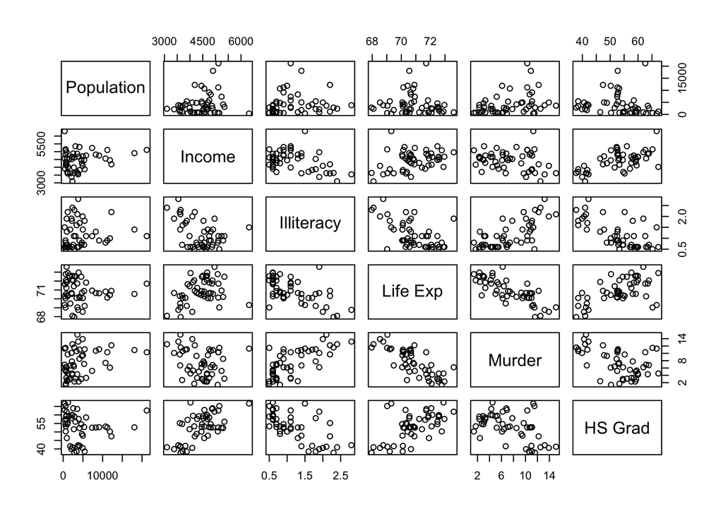

```r
pairs(states)
```

```r
cor(states, method="spearman")
```

```
##            Population     Income Illiteracy   Life Exp     Murder
## Population  1.0000000  0.1246098  0.3130496 -0.1040171  0.3457401
## Income      0.1246098  1.0000000 -0.3145948  0.3241050 -0.2174623
## Illiteracy  0.3130496 -0.3145948  1.0000000 -0.5553735  0.6723592
## Life Exp   -0.1040171  0.3241050 -0.5553735  1.0000000 -0.7802406
## Murder      0.3457401 -0.2174623  0.6723592 -0.7802406  1.0000000
## HS Grad    -0.3833649  0.5104809 -0.6545396  0.5239410 -0.4367330
##               HS Grad
## Population -0.3833649
## Income      0.5104809
## Illiteracy -0.6545396
## Life Exp    0.5239410
## Murder     -0.4367330
## HS Grad     1.0000000
```

```r
x <- states[,c("Population", "Income", "Illiteracy", "HS Grad")]
y <- states[,c("Life Exp", "Murder")]
cor(x,y)
```

```
##               Life Exp     Murder
## Population -0.06805195  0.3436428
## Income      0.34025534 -0.2300776
## Illiteracy -0.58847793  0.7029752
## HS Grad     0.58221620 -0.4879710
```

## 相关性的显著水平测试

h0：无关

```r
cor.test(states[,3], states[,5])
```

```
##
##  Pearson's product-moment correlation
##
## data:  states[, 3] and states[, 5]
## t = 6.8479, df = 48, p-value = 1.258e-08
## alternative hypothesis: true correlation is not equal to 0
## 95 percent confidence interval:
##  0.5279280 0.8207295
## sample estimates:
##       cor
## 0.7029752
```

```r
corr.test(states, use="complete")
```

```
## Call:corr.test(x = states, use = "complete")
## Correlation matrix
##            Population Income Illiteracy Life Exp Murder HS Grad
## Population       1.00   0.21       0.11    -0.07   0.34   -0.10
## Income           0.21   1.00      -0.44     0.34  -0.23    0.62
## Illiteracy       0.11  -0.44       1.00    -0.59   0.70   -0.66
## Life Exp        -0.07   0.34      -0.59     1.00  -0.78    0.58
## Murder           0.34  -0.23       0.70    -0.78   1.00   -0.49
## HS Grad         -0.10   0.62      -0.66     0.58  -0.49    1.00
## Sample Size
## [1] 50
## Probability values (Entries above the diagonal are adjusted for multiple tests.)
##            Population Income Illiteracy Life Exp Murder HS Grad
## Population       0.00   0.59       1.00      1.0   0.10       1
## Income           0.15   0.00       0.01      0.1   0.54       0
## Illiteracy       0.46   0.00       0.00      0.0   0.00       0
## Life Exp         0.64   0.02       0.00      0.0   0.00       0
## Murder           0.01   0.11       0.00      0.0   0.00       0
## HS Grad          0.50   0.00       0.00      0.0   0.00       0
##
##  To see confidence intervals of the correlations, print with the short=FALSE option
```

# t 检验

t 检验常用来进行两组之间的比较，可用来回答如下问题： 1. 患者在使用了新药后是不是比使用原来的药有了更好的提升？ 2. 两个教学手段哪个更有效率？

## 独立性 t 检验

```r
library(MASS)
t.test(Prob ~ So, data = UScrime)
```

```
##
##  Welch Two Sample t-test
##
## data:  Prob by So
## t = -3.8954, df = 24.925, p-value = 0.0006506
## alternative hypothesis: true difference in means is not equal to 0
## 95 percent confidence interval:
##  -0.03852569 -0.01187439
## sample estimates:
## mean in group 0 mean in group 1
##      0.03851265      0.06371269
```

因为 **p < .001** 所以我们可以**拒绝**掉：南部州和非南部州有相同的坐牢概率这个假设。

## 非独立性 t 检验

```r
sapply(UScrime[c("U1","U2")], function(x)(c(mean=mean(x),sd=sd(x))))
```

```
##            U1       U2
## mean 95.46809 33.97872
## sd   18.02878  8.44545
```

```r
with(UScrime, t.test(U1, U2, paired=TRUE))
```

```
##
##  Paired t-test
##
## data:  U1 and U2
## t = 32.407, df = 46, p-value < 2.2e-16
## alternative hypothesis: true difference in means is not equal to 0
## 95 percent confidence interval:
##  57.67003 65.30870
## sample estimates:
## mean of the differences
##                61.48936
```

拒绝原假设（不同年龄段有相同的坐牢率），即年轻人比中年人更容易坐牢。

# 非参数检验

## 比较两个组

如果两个组是独立的，我们可以用 Wilcoxon rank sum test（Mann–Whitney U test），来评估观测值是不是都是从相同的概率分布中采样出来的（例如：在A群人中拿到高分的概率是不是比B群要高）。

```r
with(UScrime, by(Prob, So, median))
```

```
## So: 0
## [1] 0.038201
## --------------------------------------------------------
## So: 1
## [1] 0.055552
```

```r
wilcox.test(Prob ~ So, data=UScrime)
```

```
##
##  Wilcoxon rank sum test
##
## data:  Prob by So
## W = 81, p-value = 8.488e-05
## alternative hypothesis: true location shift is not equal to 0
```

同样我们还是以 p < 0.001 拒绝掉原假设。

```r
sapply(UScrime[c("U1","U2")], median)
```

```
## U1 U2
## 92 34
```

```r
with(UScrime, wilcox.test(U1, U2, paired=TRUE))
```

```
##
##  Wilcoxon signed rank test with continuity correction
##
## data:  U1 and U2
## V = 1128, p-value = 2.464e-09
## alternative hypothesis: true location shift is not equal to 0
```

以上我们可以看到非参数检验和 t 检验得到了相同结论。

## 比较更多组

```r
states <- as.data.frame(cbind(state.region, state.x77))
kruskal.test(Illiteracy ~ state.region, data=states)
```

```
##
##  Kruskal-Wallis rank sum test
##
## data:  Illiteracy by state.region
## Kruskal-Wallis chi-squared = 22.672, df = 3, p-value = 4.726e-05
```

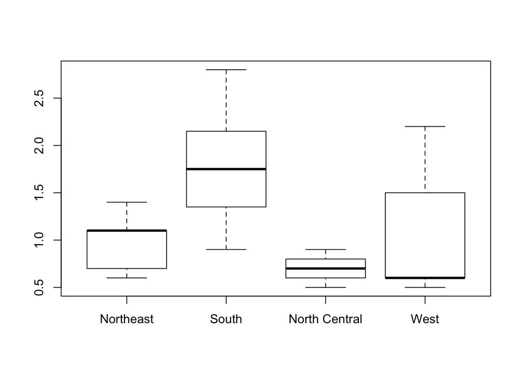

```r
plot(state.region, state.x77[,3])
```

显著性检验显示出该国的四个区域，文盲率并不相同，虽然我们可以拒绝原假设，因为 region 有多个，我们并不能判断出哪些 region 是与其它显著不同的。为了回答这样一个问题，我们可以每次挑出两个组来使用 Mann–Whitney U test，当然一种更好的方法是同时进行多组比较。

```r
class <- state.region
var <- state.x77[,c("Illiteracy")]
mydata <- as.data.frame(cbind(class, var))
rm(class, var)
# library(npmc)
# summary(npmc(mydata), type="BF")
aggregate(mydata, by=list(mydata$class), median)
```

```
##   Group.1 class  var
## 1       1     1 1.10
## 2       2     2 1.75
## 3       3     3 0.70
## 4       4     4 0.60
```